# Economic Policy and the Federal Budget

POLS 2311: Government of the United States

## Agenda

- Economic Policy Basics
- Four Theories of Economic Policy
- The Major Players: Congress and the Fed
- The Federal Budget Process
- Contemporary Debates

# Economic Policy Basics

## Definitions

- **Deficit**: spending exceeds revenue in a given year
- **National debt**: the accumulation of deficits over time
- **Gross Domestic Product (GDP)**: all goods and services produced in an economy during a given year
- **Inflation**: the increase in the prices of goods and services over time
- **Unemployment rate**: the number of unemployed people expressed as a percentage of the total labor force

## Federal Budget Deficit or Surplus, FY 1930–2023

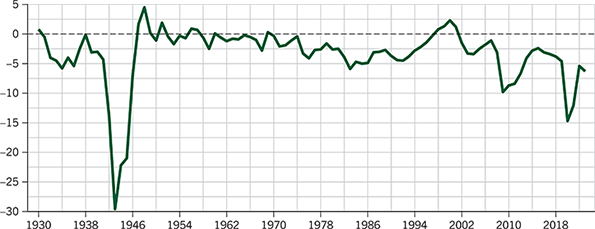

## National Debt

[figure not shown]

## Gross Domestic Product

[figure not shown]

## Inflation

[figure not shown]

## Unemployment Rate

[figure not shown]

## The Economy and Elections

- Politicians prioritize quick economic wins, especially before elections
- Government benefits often increase in election years
- Fixing one problem (e.g., unemployment) can worsen another (e.g., inflation)
- Presidents can lose elections due to economic downturns largely outside their control
- No perfect strategy exists for balancing inflation, taxes, and spending

## Belief the Government Spends Too Much on Various Policies

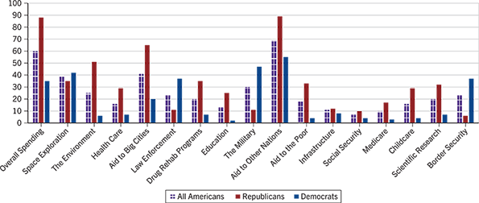

## Beliefs about the Tax System

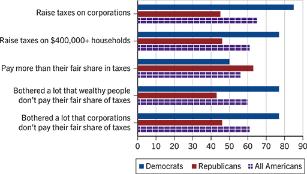

# Four Theories of Economic Policy

## Monetarism

**Monetarism**

- Economic stability is best achieved through control of the money supply

[figure not shown]

## Keynesianism

**Keynesianism**

- Government should increase spending during a recession and cut spending during inflation to stabilize the economy

[figure not shown]

## Planning

**Planning**

- The economy can be improved through government plans, such as wage and price controls

[figure not shown]

## Supply-Side Economics

**Supply-Side Economics**

- The economy is stimulated through lower taxes and fewer regulations
- *Laffer Curve*

[figure not shown]

# The Major Players

## The Federal Reserve System: Monetary Policy

- **Monetary policy**: *Manipulating the **interest rate** and **money supply** to influence the operation of the economy*
- **The Federal Reserve System**: *Federal Reserve Act* of 1913
  - **Federal Reserve Board**: Seven governors, appointed by the president with Senate consent, serve non-renewable 14-year terms — removable only “for cause”
  - **Fed Chairman**: Chair of the board
  - 12 regional Federal Reserve Banks

## The Federal Reserve System: Monetary Policy

- Twin goals of economic growth and low *inflation*
- Buys and sells securities (open-market operations)
- Regulates bank reserve requirements
- Sets the interest rate charged to banks

## Why Fed Independence?

- Congress feared direct presidential control over monetary policy would produce a permanent inflationary bias timed to election cycles
- Ahead of the 1972 election, Nixon pressured Fed Chair Arthur Burns: *“The Fed must loosen — it must risk inflation”*
  - Burns complied — contributing to the inflation of the 1970s

## *Trump v. Cook* (2026): Testing Fed Independence

- President Trump attempted to remove Fed Governor Lisa Cook “for cause,” citing mortgage fraud allegations
- The Court held 5-4 that Cook was entitled to notice and a hearing
- The Court declined to extend the **Unitary Executive Theory** to the Fed — citing its “unique historical status”
- Left the Fed’s independence in a provisional, not settled, state

## Congress: Fiscal Policy

- **Fiscal policy**: *The deliberate use of the government’s **taxing** and **spending** powers to stimulate or restrain the economy*
- Government spending
- Taxes
- Some oversight of the Federal Reserve
- Foreign trade
- Must approve all taxes and almost all expenditures — no wage or price controls without its consent

# The Federal Budget Process

# *Budgeting is, at its core, the fundamental decision about the use of scare resources from the people*

## Congress’s Power of the Purse

- Article I: Congress has the power to “lay and collect Taxes, Duties, Imposts and Excises”
- “No Money shall be drawn from the Treasury, but in Consequence of Appropriations made by law”
- No single piece of legislation creates “the budget” — a mix of permanent law, multi-year law, and annual appropriations

## Mandatory vs. Discretionary Spending

- **Mandatory spending** (~61% of the budget): the authorizing law itself sets the funding — Social Security, Medicare, Medicaid, SNAP
- **Discretionary spending** (~26%): Congress sets funding annually through the appropriations process — defense, agency budgets
- The remainder: interest on the debt
- Mandatory spending is why cutting the federal budget is harder than it looks — most of it isn’t up for annual debate

## Government Revenues and Expenditures by Type

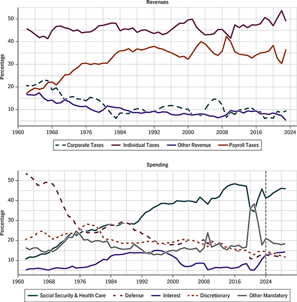

## Federal Taxes on Income, Top Percentage Rates, 1913–2023

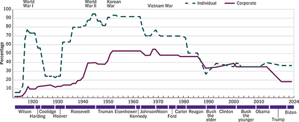

## The Budget Process

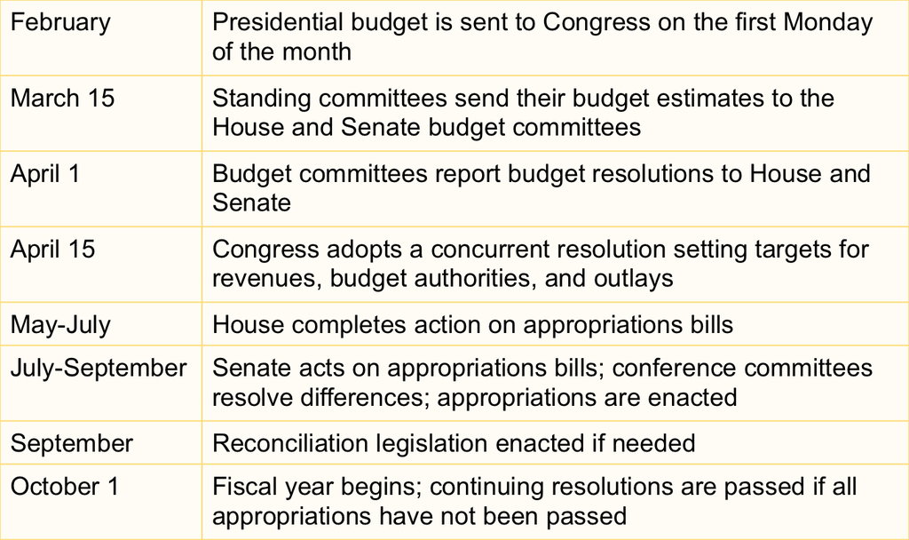

## The President’s Budget Request

- Opens the annual cycle — nominally due the first Monday in February
- Developed through OMB and federal agencies, beginning the prior spring
- Signals the administration’s fiscal priorities across a ten-year window

## The Congressional Budget Resolution

- A **concurrent resolution** — not signed by the president, and cannot be filibustered
- Sets spending ceilings and a revenue floor across 19 budget “functions”
- Due April 15 — but often passes late, or not at all
- Excludes Social Security’s trust fund

## Appropriations and Shutdowns

- 12 annual appropriations bills fund discretionary programs, often combined into omnibus packages
- Appropriations have not been finished by October 1 in 42 of the last 45 years
- Missing the deadline requires a **continuing resolution (CR)** — funding at current levels for a set period
- Failing to pass a CR produces a **government shutdown**

## Notable Government Shutdowns

- **2025**: dispute over extending Affordable Care Act health insurance subsidies — 43 days, the longest in U.S. history
- **2018–19**: border-wall funding dispute — 35 days
- **2013**: Affordable Care Act funding dispute — 16 days
- **1995–96**: Clinton-era shutdown — 21 days

## Budget Reconciliation

- An optional, expedited process triggered by a “reconciliation directive” in the budget resolution
- Filibuster-proof: capped at 20 hours of debate, passes with a simple majority
- Constrained by the **Byrd Rule** — strips provisions deemed “extraneous” to spending/tax law unless 60 senators vote to waive it
- Cannot touch Social Security, and cannot increase the deficit beyond the resolution’s window unless offset

## Reconciliation in Practice

- Originally conceived as a **deficit-reduction tool** — 16 deficit-reducing bills enacted, including the Inflation Reduction Act (2022)
- Increasingly used to *increase* the deficit: the Bush-era tax cuts (×3), the 2017 Trump tax cuts, 2021 COVID relief
- Congress now most often adopts a budget resolution specifically to unlock reconciliation — and skips one entirely when no reconciliation bill is planned

## The Debt Limit

- A fixed statutory cap on Treasury borrowing — separate from the spending and revenue laws that create the government’s obligations
- When the limit binds, it conflicts directly with other legal payment obligations (contractors, employees, Medicare, veterans, interest on the debt)

## The Debt Limit

- Congress has always raised or suspended the limit rather than default — but the process can be acrimonious
- Even the *threat* of default can dampen the broader economy

# Contemporary Debates

## Globalization

**Supporters’ View**

- Free trade lowers prices, raises incomes, and boosts global economic growth

**Critics’ Concerns**

- Free trade lowers U.S. wages, exploits foreign workers, and erodes local cultures

## Income Inequality

- The extent to which income is unevenly distributed throughout society
- Key causes: education gaps, job shifts from manufacturing to services, declining union membership
- Major policy proposals: universal pre-K, tax reform, the CHIPS Act